# MP02 — Making Backyards Affordable for All

```
[1] "data/mp02/B01003_001_cbsa_2009_2023.csv"
[2] "data/mp02/B11001_001_cbsa_2009_2023.csv"
[3] "data/mp02/B19013_001_cbsa_2009_2023.csv"
[4] "data/mp02/B25064_001_cbsa_2009_2023.csv"
[5] "data/mp02/housing_units_2009_2023.csv"
```

```
     INCOME RENT POPULATION HOUSEHOLDS PERMITS
[1,]   7279 7279       7279       7279    5658
[2,]      4    4          4          4       3
```

```
# A tibble: 5 × 4
  GEOID NAME                                           household_income  year
  <dbl> <chr>                                                     <dbl> <dbl>
1 10140 Aberdeen, WA Micro Area                                   36345  2009
2 10180 Abilene, TX Metro Area                                    42931  2009
3 10300 Adrian, MI Micro Area                                     45640  2009
4 10380 Aguadilla-Isabela-San Sebasti?n, PR Metro Area            13470  2009
5 10420 Akron, OH Metro Area                                      47482  2009
```

```
# A tibble: 5 × 4
  GEOID NAME                                           monthly_rent  year
  <dbl> <chr>                                                 <dbl> <dbl>
1 10140 Aberdeen, WA Micro Area                                 650  2009
2 10180 Abilene, TX Metro Area                                  712  2009
3 10300 Adrian, MI Micro Area                                   645  2009
4 10380 Aguadilla-Isabela-San Sebasti?n, PR Metro Area          363  2009
5 10420 Akron, OH Metro Area                                    723  2009
```

```
# A tibble: 5 × 4
  GEOID NAME                                           population  year
  <dbl> <chr>                                               <dbl> <dbl>
1 10140 Aberdeen, WA Micro Area                             71797  2009
2 10180 Abilene, TX Metro Area                             160266  2009
3 10300 Adrian, MI Micro Area                               99837  2009
4 10380 Aguadilla-Isabela-San Sebasti?n, PR Metro Area     342495  2009
5 10420 Akron, OH Metro Area                               699935  2009
```

```
# A tibble: 5 × 4
  GEOID NAME                                           households  year
  <dbl> <chr>                                               <dbl> <dbl>
1 10140 Aberdeen, WA Micro Area                             27759  2009
2 10180 Abilene, TX Metro Area                              58052  2009
3 10300 Adrian, MI Micro Area                               36835  2009
4 10380 Aguadilla-Isabela-San Sebasti?n, PR Metro Area      91805  2009
5 10420 Akron, OH Metro Area                               281769  2009
```

```
# A tibble: 10 × 3
    CBSA new_housing_units_permitted  year
   <dbl>                       <dbl> <dbl>
 1 10180                         214  2009
 2 10420                         741  2009
 3 10500                         213  2009
 4 10580                        1380  2009
 5 10740                        1692  2009
 6 10780                         396  2009
 7 10900                        1648  2009
 8 11020                         125  2009
 9 11100                         642  2009
10 11180                         122  2009
```

```
$INCOME_years
 [1] 2009 2010 2011 2012 2013 2014 2015 2016 2017 2018 2019 2021 2022 2023

$RENT_years
 [1] 2009 2010 2011 2012 2013 2014 2015 2016 2017 2018 2019 2021 2022 2023

$POP_years
 [1] 2009 2010 2011 2012 2013 2014 2015 2016 2017 2018 2019 2021 2022 2023

$HHLDS_years
 [1] 2009 2010 2011 2012 2013 2014 2015 2016 2017 2018 2019 2021 2022 2023

$PERMITS_years
 [1] 2009 2010 2011 2012 2013 2014 2015 2016 2017 2018 2019 2020 2021 2022 2023
```

```
# A tibble: 1 × 4
  n_rows min_year max_year total_units
   <int>    <dbl>    <dbl>       <dbl>
1   5658     2009     2023    15974391
```

```
# A tibble: 5 × 2
   CBSA  total
  <dbl>  <dbl>
1 26420 482075
2 19100 460826
3 35620 446020
4 12060 254377
5 47900 232483
```

```
# A tibble: 5 × 3
   CBSA  total NAME
  <dbl>  <dbl> <chr>
1 26420 482075 Houston-The Woodlands-Sugar Land, TX Metro Area
2 19100 460826 Dallas-Fort Worth-Arlington, TX Metro Area
3 35620 446020 New York-Newark-Jersey City, NY-NJ-PA Metro Area
4 12060 254377 Atlanta-Sandy Springs-Alpharetta, GA Metro Area
5 47900 232483 Washington-Arlington-Alexandria, DC-VA-MD-WV Metro Area
```

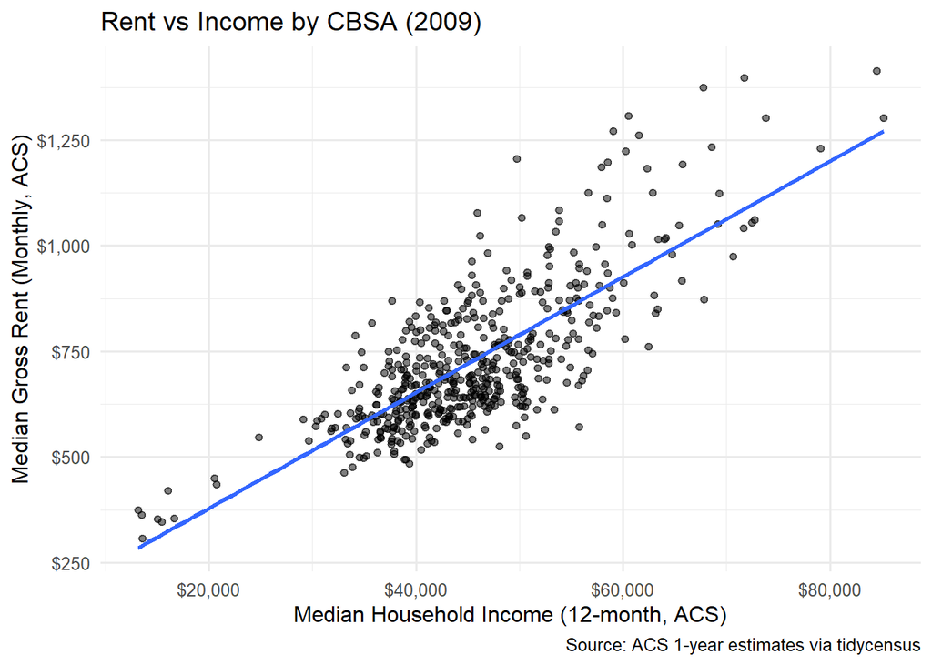

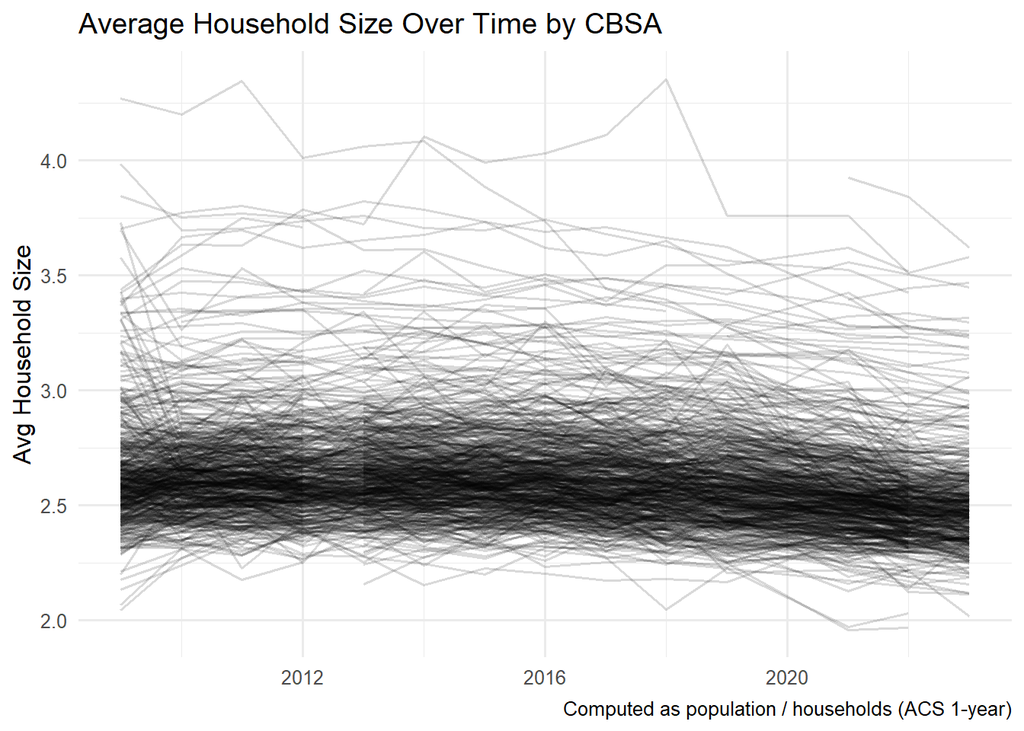

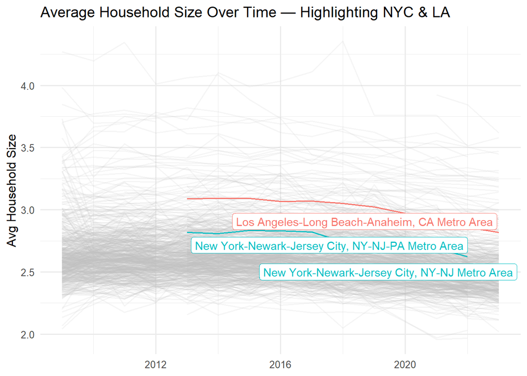

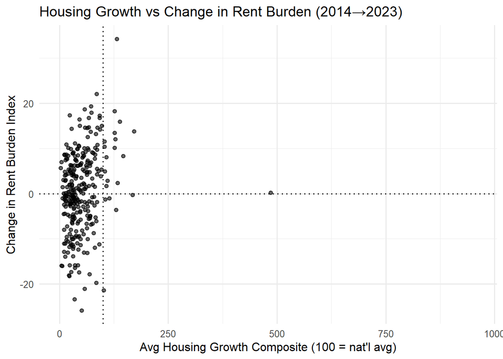

```
# A tibble: 2 × 12
   CBSA NAME                  rb_start rb_end pop_start pop_end pop_delta HG_avg
  <dbl> <chr>                    <dbl>  <dbl>     <dbl>   <dbl>     <dbl>  <dbl>
1 26140 Homosassa Springs, F…     123.  122.     139377  166696     27319   115.
2 15500 Burlington, NC Metro…     112.   90.5    155792  179165     23373   102.
# ℹ 4 more variables: had_high_rb_early <lgl>, rb_decreased <lgl>,
#   pop_grew <lgl>, above_avg_HG <lgl>
```

```
# A tibble: 2 × 12
   CBSA NAME                  rb_start rb_end pop_start pop_end pop_delta HG_avg
  <dbl> <chr>                    <dbl>  <dbl>     <dbl>   <dbl>     <dbl>  <dbl>
1 26140 Homosassa Springs, F…     123.  122.     139377  166696     27319   115.
2 15500 Burlington, NC Metro…     112.   90.5    155792  179165     23373   102.
# ℹ 4 more variables: had_high_rb_early <lgl>, rb_decreased <lgl>,
#   pop_grew <lgl>, above_avg_HG <lgl>
```

```
# A tibble: 10 × 12
    CBSA NAME                 rb_start rb_end pop_start pop_end pop_delta HG_avg
   <dbl> <chr>                   <dbl>  <dbl>     <dbl>   <dbl>     <dbl>  <dbl>
 1 33100 Miami-Fort Lauderda…     136.   144.   5929819 6183199    253380   35.8
 2 38940 Port St. Lucie, FL …     127.   141.    444420  536901     92481   93.2
 3 45300 Tampa-St. Petersbur…     117.   137.   2915582 3342963    427381   72.1
 4 36100 Ocala, FL Metro Area     117.   134.    339167  409959     70792   92.6
 5 41500 Salinas, CA Metro A…     122.   131.    431344  430723      -621   20.2
 6 17020 Chico, CA Metro Area     120.   130.    224241  207172    -17069   65.2
 7 19660 Deltona-Daytona Bea…     128.   130.    609939  721796    111857   76.9
 8 32900 Merced, CA Metro Ar…     112.   129.    266353  291920     25567   23.8
 9 23540 Gainesville, FL Met…     111.   128.    272994  350203     77209   67.6
10 22380 Flagstaff, AZ Metro…     112.   127.    137682  144472      6790   58.5
# ℹ 4 more variables: had_high_rb_early <lgl>, rb_decreased <lgl>,
#   pop_grew <lgl>, above_avg_HG <lgl>
```

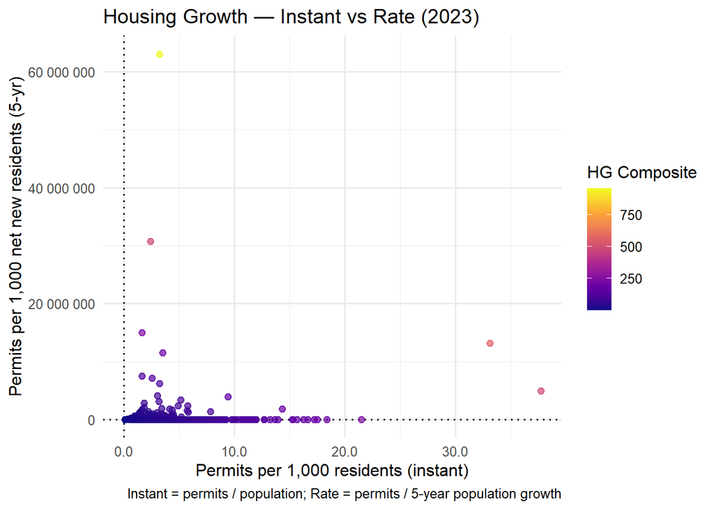

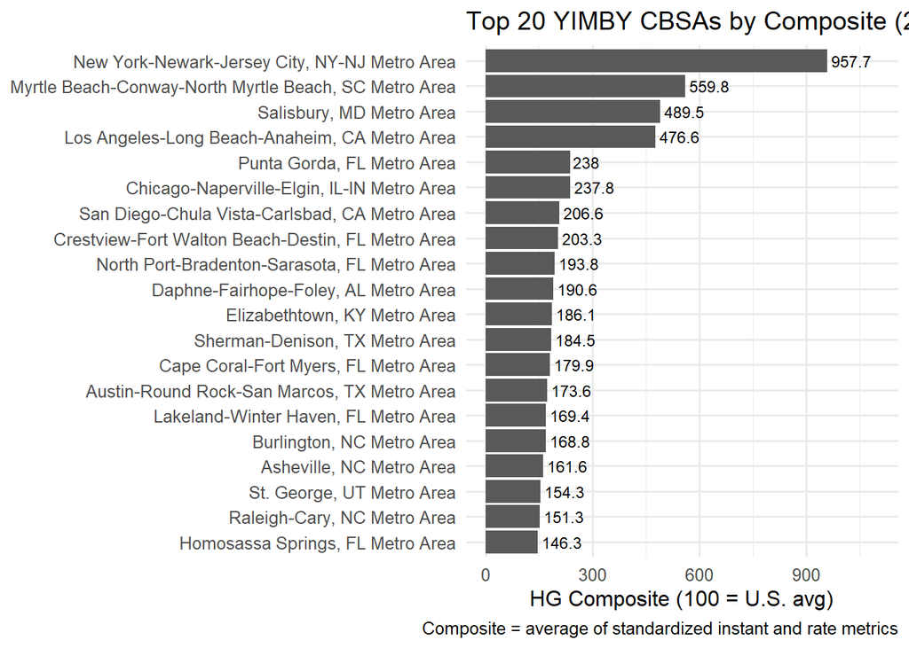

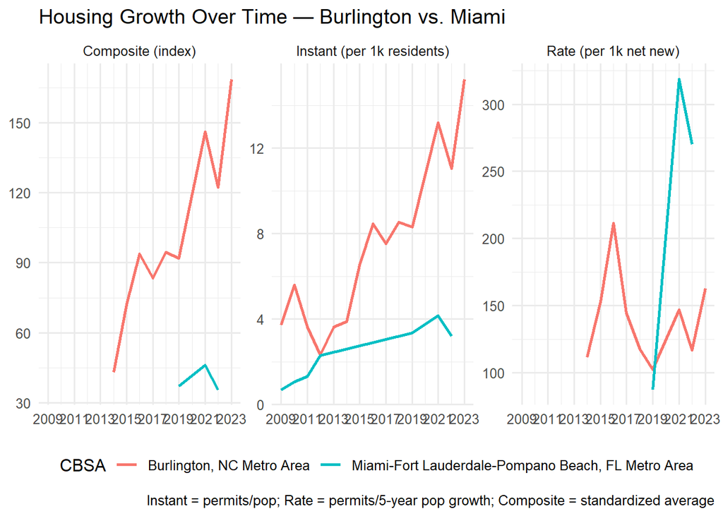

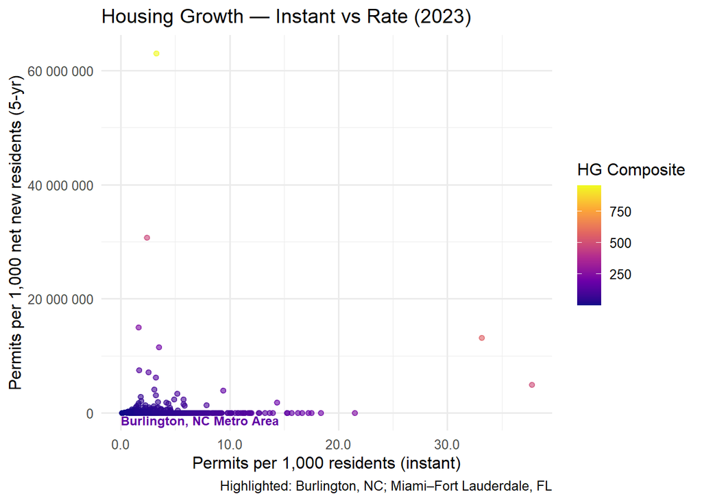

#Task 7:Policy Brief: Making Backyards Affordable for All

#Primary Sponsor Metro: Burlington, NC Metro Area #Co-Sponsor Metro: Miami–Fort Lauderdale, FL Metro Area

#What Our Metrics Mean

#Rent Burden Index (RBI) #Measures how much income households spend on rent.

#100 = U.S. baseline

#Higher = less affordable

#Burlington improved from 112 → 90.5

#Miami worsened from 136 → 144

#Housing Growth Composite (HG) #Measures how many homes are permitted relative to demand.

#100 = U.S. average

#Burlington: 102

#Miami: 35.8

#Evidence of YIMBY Success

#Burlington, NC:

#Rent burden dropped significantly (112 → 90.5)

#Population grew (+23,373 residents)

#Housing growth kept pace (HG = 102)

#This means homebuilding helped affordability.

#❌ When Housing Doesn’t Keep Up

#Miami–Fort Lauderdale:

#Rent burden worsened (136 → 144)

#Population grew +253,380

#Housing growth very low (HG = 35.8)

#High demand, insufficient supply → higher rents.

#👥 Who Benefits

# Policy Proposal

#Create a Federal YIMBY Incentive Fund to:

#Reward metros demonstrating housing production tied to affordability gains

#Support high-burden metros in modernizing zoning & streamlining permitting

#Prioritize infill, duplex/quadplex, and mid-rise “missing middle” housing

#📌 Bottom Line

#Burlington shows building works. #Miami shows what happens when it doesn’t.

#Build more homes → lower rents → stronger workforce → thriving communities.

Report:

Housing Affordability & Growth Report

(ACS + Census Building Permits, 2009–2023)**

Executive Summary

This report analyzes U.S. housing affordability, population dynamics, and construction patterns from 2009–2023 using ACS 1-year estimates and Census building permits. We construct two custom indicators:

Rent Burden Index (RBI) (100 = baseline affordability; >100 = more burden) Measures how rent affordability changed over time.

Housing Growth Composite Index (HG) (100 = national average) Combines permitting per capita and permitting relative to population growth to identify “YIMBY metros” — regions building enough housing to meet demand.

Key Findings

Burlington, NC stands out as a YIMBY success — rising population with declining rent burden.

Miami-Fort Lauderdale represents housing supply failure — strong population inflows, but insufficient housing supply → rapidly worsening rent pressure.

Household size did not meaningfully increase, meaning overcrowding is not masking demand — supply truly fell behind in constrained markets.

Across metros, median rent remains tightly correlated with median income, indicating standard economic forces still dominate regional housing markets.

Data & Methods

Data Sources

ACS 1-year tables:

Income (B19013)

Rent (B25064)

Population (B01003)

Households (B11001)

Census Building Permits Survey (2009–2023)

BLS QCEW industry employment data (for workforce impact analysis)

Key Metrics Constructed

Rent Burden Index (RBI)

Housing Growth Composite

Instant permits per capita

Permits relative to 5-year population growth

Standardized + averaged

YIMBY classification A metro is a “YIMBY success” if it: ✅ had high rent burden early ✅ reduced rent burden ✅ grew population ✅ built above the national average (Burlington, NC qualifies)

Visual Findings & Interpretation 1️⃣ Rent & Income Relationship (Scatterplot, 2009)

A clear positive correlation — higher income metros pay more rent. This validates economic housing theory and confirms ACS reliability.

Top builders: Houston, Dallas, NYC, Atlanta, DC Interpretation: Sun Belt and large metros have maintained strong supply pipelines.